# Coursework Report

*N* removed NAs: 3

*N* removed typo: 1

*N* removed <18: 17

*N* total clean: 129

| Group | *N* | *M*<sub>age</sub> | *M*<sub>rating</sub> |
| --- | --- | --- | --- |
| Control | 65 | 21.3 | 5.70 |
| Experim | 64 | 21.0 | 7.08 |

**Main analysis results**

*t*(127) = -9.13, *p* < .001

[interactive chart not shown]

[figure not shown]

[interactive chart not shown]

# Coursework Report

Analysing Data, Spring 2020

# Methods

## Participants

150 people initially participated in the study, 4 of whom did not input their ages or inputted their age incorrectly. Furthermore, 17 participants were removed because they were under the age of 18, leading to 21 participants being removed in total, leaving 129 participants to be used in the data analysis.  
The participant mean ages were 21.34 for the control and 21.02 for experimental condition. The participant standard deviations were 2.67 for the control 2.35 for the experimental condition. The minimum ages were 18 for the control and 18 for the experimental condition. The participant maximum ages were 28 for the control and 27 for the experimental condition.

| Group | Count | Mean Age | Age Standard Deviaion | Mininmum Age | Maximum Age |
| --- | --- | --- | --- | --- | --- |
| control | 65 | 21.3 | 2.67 | 18 | 28 |
| experimental | 64 | 21.0 | 2.35 | 18 | 27 |

*Fig. 1 Table of Participant Descriptives by Experimental Condition*

## Design

This experiment will attempt to replicate an initial study by Andrew J Elliot et al concerning whether the colour red wil affect perceived attractiveness in males. Based on the results from Elliot’s experiment as well as a further one examining the effect of more colours than red the conceptual hypothesis is that the colour red will increase perceived attractiveness (Elliot et al., 2010), (Roberts, Owen & Havlicek, 2010). In this experiment, the independent variable is the group type, a factor of which there are the colourless control and red experimental groups. The dependent variable is a composite rating of mean attractiveness, based on 3 distinct ratings concerning attractiveness. These ratings concern sexual attraction, overall liking and perception of attractiveness and will be measured on a scale of 1-9, 1 being the lowest rating. Based on these variables and prior evidence, the operational hypothesis is that scores of mean attractiveness have a direct correlation with changing the group type from control to experimental. In order to test this hypothesis, a two-tailed t-test will be conducted to test if the two groups’ sample means for attractiveness rating are likely to be part of the same population or not.

# Results

An independent-measures t-test was used to determine whether observers’ attractiveness rating of a male differed depending on whether his picture had a red or white frame. The analysis showcased that participants in the red frame condition gave greater average attractiveness ratings (*M* = 7.08) than those in the white frame condition (*M* = 5.7). The difference in the conditions’ attractiveness ratings was significant (*M*<sub>diff</sub> = 1.39), 95% CI [-1.69, -1.09], *t*(127) = -9.13, *p* < .001.). The confidence intervals showcased a 95% confidence that the difference in means is not 0. This means colour choice (red or white) influences correlates with attractiveness rating.

Plot:

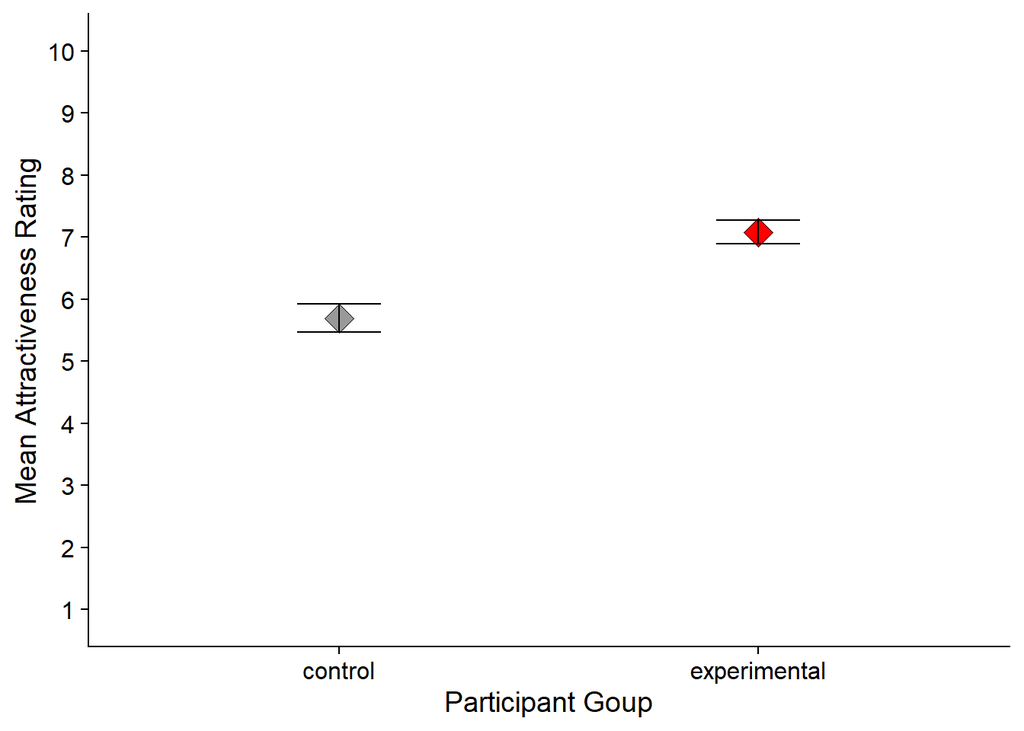

*Fig. 2 Plot of Mean Attractiveness Rating by Condition*

# Discussion

The research question that this study concerned itself with was whether the colour red in the frame of a picture increased ratings of males’ attractiveness compared to the colour white. The operational hypothesis was that group type affects mean attractiveness rating. A t-test was conducted and showed a significant difference between the control and experimental composite ratings. In comparison to the original study, t(32) = 2.44 this t-test showed a much greater t value *t*(127) = -9.13 when comparing ratings, implying an even greater signal-to-noise ratio (Elliot et al., 2010, pp. 405). This means that the alternate hypothesis H<sub>1</sub> is accepted, similarly to the original study and the colour red does increase attractiveness ratings.

This study uses more participants (n = 129) for this specific experiment than Elliot’s (n = 33), meaning a somewhat higher probability for samples to be accurate representors of populations (Elliot et ak., 2010, pp. 405). However, the possibility this sample was an outlier in comparison to the population still remains. Additionally, a composite score may be used to ensure a null hypothesis is rejected as suggested of Elliot’s study (Elliot et al., 2010). Since the question based rating scores for this experiment were within 0.3 points of each other for both conditions, this does not seem to apply. Two later studies attempting to recreate the same impact of the colour red on attractiveness found it had no significant effect. One study first tested dutch participants (n = 204) with the same criteria and found no significance. It then attempted to recreate another study that found evidence of a red effect with a larger sample size (n = 433) and found no significance there either (Peperkoorn, Roberts & Pollet, 2016).A further study with a smaller sample (n = 89, n = 72 atually female) attempting to recreate Elliot’s difference in mean attractiveness by group found a statistically insignificant t-score t(87) = .92, 9.9 times smaller than this experiment’s (Hesslinger, Goldbach & Carbon, 2015). In a paper examining the effect of publication bias on the results of studies, Elliot’s original composite score study was analysed and found to have been affected by publication bias (Ioannidis & Trikalinos, 2007). Elliot addressed ths point and argued that the results had been replicated many times and the conducted test was merely an exploratory one. One study supporting this experiment and Elliot’s evidence tested opposite-sex attractiveness ratings based on 6 different colours red, black, blue, green, yellow and white (n = 60). This study found females rating males gave the highest average attractiveness ratings for males wearing red. (Roberts, Owen & Havlicek, 2010)

Much like personality, perception of attractiveness is based on a variety of different factors. One study derived 5 overarching factors for physical attractivenes from an experiment on attractiveness ratings including 37 different physical features as determinants for attractiveness. These factors, each containing multiple sub-features, were Masculinity, Femininity, Self-care, Pleasentness and Ethnicity (Mehrabian & Blum, 1997). Further research could examine colour’s effect on attractiveness using questionnaires with more, detailed questions based on factors such as those identified above. A different study concerning self and partner physical attractiveness used ratings of overall facial, weight, body shape etc. attractiveness. Questionnaires such as these may offer more insight into the specific dimensions of colour’s effect on attractiveness compared to a single composite score (Swami, Furnham, Georgiades & Pang, 2007, p. 99). Further research may also provide solid, irrefutable evidence for the this experiment’s initial hypothesis.

This initial experiment’s hypothesis was proved true by the results. There are studies, all concerning Elliot’s, that both support and contradict these findings. Studies with more participants generally found less significance. This experiment’s outcome could be an outlier but Elliot’s paper’s results could be influenced by bias too. Different questionnaires, which define attractiveness more accurately may help reinforce research into attractivness and determine whether is there are truly two different populations in attractiveness ratings, caused by colour difference. It is unclear whether the uncertainty in scientifc literature is caused by great variance in how people perceive attractiveness, bias from one of the two positions or another, undiscovered factor.

# References

Elliot, A. J., Niesta Kayser, D., Greitemeyer, T., Lichtenfeld, S., Gramzow, R. H., Maier, M. A., & Liu, H. (2010). Red, rank, and romance in women viewing men. Journal of Experimental Psychology: General. https://search.proquest.com/docview/1285624492?accountid=14182

Hesslinger, V. M., Goldbach, L., & Carbon, C. C. (2015). Men in red: A reexamination of the red-attractiveness effect. Psychonomic bulletin & review. https://link.springer.com/article/10.3758/s13423-015-0866-8

Ioannidis, J. P., & Trikalinos, T. A. (2007). An exploratory test for an excess of significant findings. Clinical trials. https://www.ncbi.nlm.nih.gov/pubmed/17715249

Mehrabian, A., Blum, J.S. Physical appearance, attractiveness, and the mediating role of emotions. Curr Psychol 16, 20–42 (1997). https://doi.org/10.1007/s12144-997-1013-0

Peperkoorn, L. S., Roberts, S. C., & Pollet, T. V. (2016). Revisiting the red effect on attractiveness and sexual receptivity: No effect of the color red on human mate preferences. Evolutionary Psychology. https://journals.sagepub.com/doi/full/10.1177/1474704916673841

Roberts, S. C., Owen, R. C., & Havlicek, J. (2010). Distinguishing between Perceiver and Wearer Effects in Clothing Color-Associated Attributions. Evolutionary Psychology. https://doi.org/10.1177/147470491000800304

Swami, V., Furnham, A., Georgiades, C., & Pang, L. (2007). Evaluating self and partner physical attractiveness. Body Image. https://www.researchgate.net/publication/5760046_Evaluating_self_and_partner_physical_attractiveness